# SI 544 Day 2: Visualization

## Barplots for 2

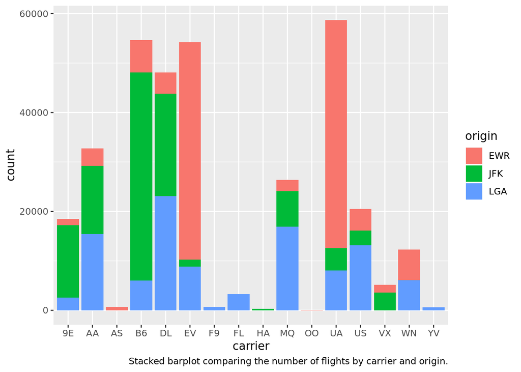

```r
ggplot(data = flights, mapping = aes(x = carrier, fill = origin)) +
  geom_bar() +
  labs(caption="Stacked barplot comparing the number of flights by carrier and origin.")
```

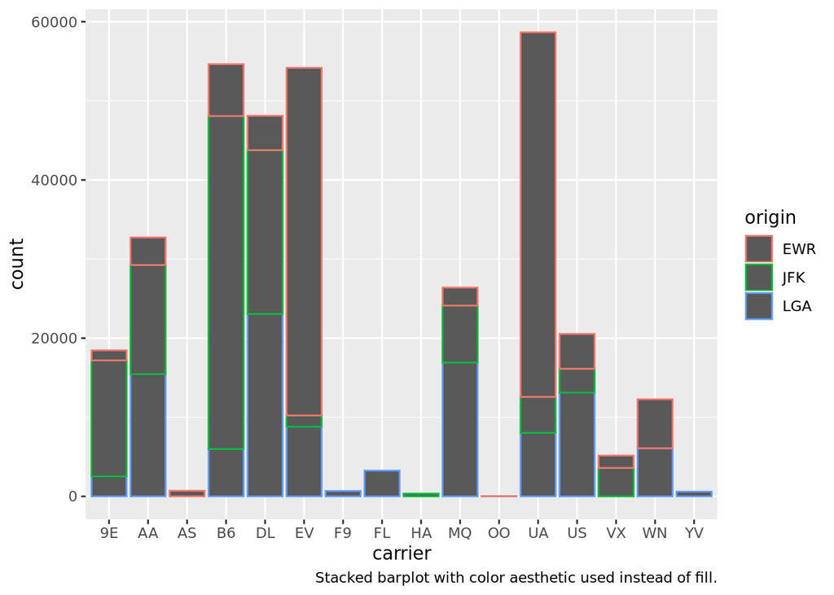

```r
ggplot(data = flights, mapping = aes(x = carrier, color = origin)) +
  geom_bar() +
  labs(caption="Stacked barplot with color aesthetic used instead of fill.")
```

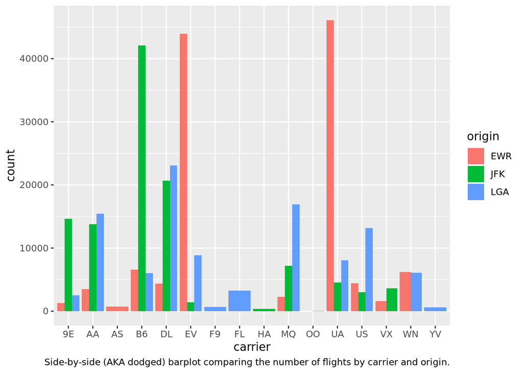

```r
ggplot(data = flights, mapping = aes(x = carrier, fill = origin)) +
  geom_bar(position = "dodge") +
  labs(caption="Side-by-side (AKA dodged) barplot comparing the number of flights by carrier and origin.")
```

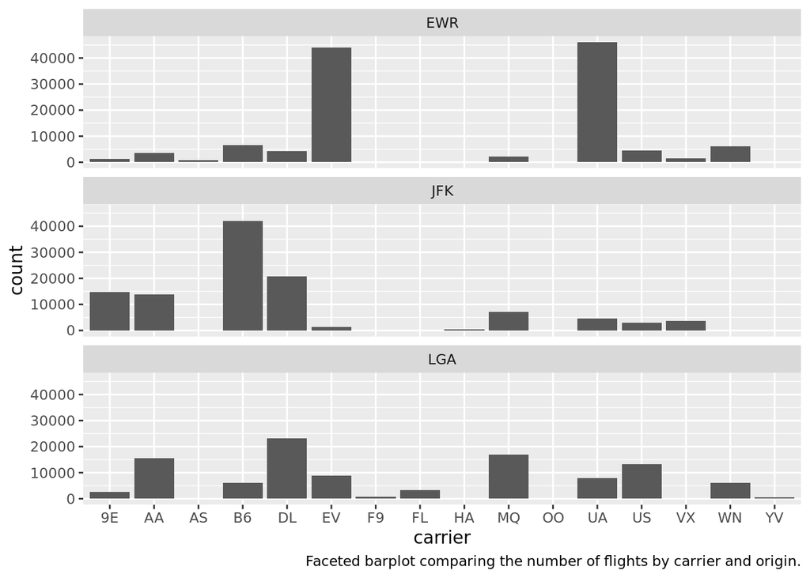

```r
ggplot(data = flights, mapping = aes(x = carrier)) +
  geom_bar() +
  facet_wrap(~ origin, ncol = 1) +
  labs(caption="Faceted barplot comparing the number of flights by carrier and origin.")
```

## Learning Check (LC3.30) Why should pie charts be avoided and replaced by barplots?

barplots represent even the complex data in more clearer and sorted manner than pie charts

## Learning Check (LC3.31) Why do you think people continue to use pie charts?

to avoid detailed representation of data so that even common people can comprehend the results.

END OF NOTEBOOK!

Please remember to Knit this notebook into HTML and submit the HTML version via Canvas.